# Interstate Migration as a Chord Diagram

Everybody moved, almost nobody left: a year of state-to-state flows in one circle, and the grouping the circle demands

Democracy’s Data

Last updated September 13, 2026 at 10:53a EDT

Americans tell the story of their own migration as an exodus. The Northeast empties into the South, California empties into Texas, and whole regions are winners or losers. The story matters to democracy because House seats and electoral votes really do follow the movers. But is the movement actually one-way? Or do the flows mostly run in both directions at once and cancel?

The record that can answer this is a survey. In the year the American Community Survey last measured it, 7,157,607 people in the United States lived in a different state than they had lived in twelve months earlier. Another 29,888,154 moved within their own state, and 2,552,193 arrived from abroad. The between-state moves are published as a matrix: 52 origins by 52 destinations, 2,652 ordered pairs. Each pair carries an estimate and a margin of error, which says how far off that estimate could be.

That matrix is the cleanest flow data in American demography, and it is almost impossible to look at. A **chord diagram** is the form built for exactly this shape of data. It is a circle whose rim is the set of places, with a ribbon joining each pair, wide where the flow is heavy. It will not take 2,652 ribbons. Getting the matrix small enough to draw is most of the work in this brief, and it is where the arguing should happen.

## The test

The flows are the Census Bureau’s *State-to-State Migration Flows* table, from the 2024 American Community Survey one-year estimates. The ACS reaches roughly 3.5 million addresses a year and asks each household where it lived one year ago; that one question is the country’s entire measurement of moving. The American Community Survey chapter is the survey’s biography: who is in it, how it is weighted up to the country, and why a margin of error stands beside every estimate it publishes.

The numbers here are the same tables the migration brief hands over, suppressed cells and all, so the two documents cannot silently disagree about a number. The test itself is the one the exodus story begs for. Group the states, add up the flow in each direction between every pair of groups, and measure how much is net and how much cancels.

## The data

One row of the flow table is an ordered pair of states. Direction is a column, not a sign: Middle Atlantic to South Atlantic and South Atlantic to Middle Atlantic are two different rows holding two different numbers, and this brief turns on the fact that both are large.

| From | To | People | Note |
| --- | --- | --- | --- |
| Middle Atlantic | South Atlantic | 307,170 | the larger direction |
| South Atlantic | Middle Atlantic | 186,857 | the smaller direction |

After grouping, the working table keeps six columns:

| Column | What it holds | Measurement |
| --- | --- | --- |
| from | the group people left | categorical |
| to | the group they arrived in; when it equals `from`, they changed state without leaving the group | categorical |
| est | how many people the ACS estimates made that move in the year | count |
| moe | the margin of error on that estimate, at 90% confidence | continuous |
| cells | how many state-to-state pairs were added together to make this cell | count |
| suppressed | how many of those pairs the Census would not release | count |

The states are grouped into the Census Bureau’s own **nine divisions**, the clusters of neighbouring states — New England, the Middle Atlantic, the Pacific and so on — that the Bureau uses to summarise the country, with Puerto Rico carried as a tenth group.[^1] The Bureau’s divisions cover only the fifty states and the District of Columbia, and 36,401 people left Puerto Rico for a state that year. The list of which state belongs to which division is the one this book’s regional-shift brief uses, checked there against the Bureau’s published region totals for every decade since 1910.

| Region | Division | States | Population | House seats |
| --- | --- | --- | --- | --- |
| Northeast | Middle Atlantic | 3 | 42,020,276 | 55 |
| Northeast | New England | 6 | 15,250,253 | 21 |
| Midwest | East North Central | 5 | 47,144,543 | 62 |
| Midwest | West North Central | 7 | 21,736,206 | 29 |
| South | East South Central | 4 | 19,706,473 | 26 |
| South | South Atlantic | 9 | 68,975,950 | 85 |
| South | West South Central | 4 | 42,594,264 | 53 |
| West | Mountain | 8 | 25,891,835 | 33 |
| West | Pacific | 5 | 53,316,668 | 71 |
| Puerto Rico | Puerto Rico | 1 | 3,188,457 | 0 |

The grouping is a decision, not a fact about the country. **The Bureau fixed these divisions in 1910.** They put Delaware and Florida in one group, Maryland in the South, Missouri in the Midwest, and Texas with Arkansas and Oklahoma. Every sentence below about “the South” is a sentence about that list of states, and a different list would draw a different circle from identical data.

Two cleaning decisions travel with the grouping, and both push in a known direction. First, **279 of the 2,652 state pairs are not published at all**: the Bureau releases no estimate when too few sampled households made a move. Aggregation adds them as zeros, because there is nothing else to add, so the group totals run slightly low. `matrix.csv` therefore carries a count of suppressed pairs in every cell, and 78 of the 99 division-to-division cells contain at least one. A cell assembled mostly out of suppressed pairs cannot pass itself off as a measurement.

Second, **margins of error on the grouped cells are added in quadrature**, which is the Bureau’s own instruction for a sum of published estimates:[^2] square each margin, add the squares, and take the square root of the total. The largest exchange in the country shows the arithmetic. Middle Atlantic to South Atlantic carries a margin of ±16,182, and the return flow ±13,094. The net between them is the difference of the two estimates, and its margin is the square root of 16,182² plus 13,094², which comes to ±20,816 — less than the two added outright, because two errors are unlikely to both fall the same way. That rule assumes the errors are independent, and cells from a single survey are not quite independent. So the margins below are approximate, and if they are wrong they are too small.

> **Before you read on, commit to a number.** Roughly 7.2 million Americans changed state in a year. **What share of them do you think crossed a Census division boundary** — left the Northeast for the South, say — rather than moving to a neighbouring state inside the same division? Write down a percentage.

## What it says about democracy

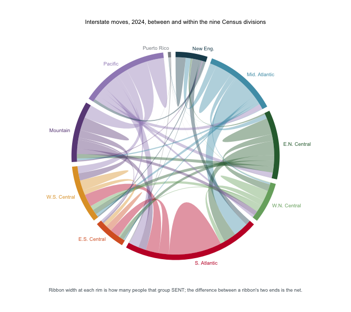

**Figure 1. A year of interstate migration, 2024.** A chord diagram fits because the data is a square grid of flows among the same ten groups, and the circle is the one form that shows every pair at once. Each rim segment is one division, sized by how many people left it. A ribbon’s width where it meets the rim is how many people that division sent, so **the taper of a ribbon is the net flow**; ribbons take the colour of whichever division sent more. Click a rim segment to isolate it; the buttons switch to the four-region grouping and drop the within-division ribbons.

Now the prediction. **26.9% of interstate moves do not cross a division boundary.** Of 7,188,344 moves in the grid, 1,935,522 were to another state in the same division: New York to New Jersey, Virginia to Maryland, Ohio to Michigan. They are the fat lens-shaped ribbons sitting on the rim in Figure 1. The button that hides them is worth pressing twice, because with them gone the circle looks busier and the country looks more mobile than it is.

That is the first thing the grouping does. Every one of those moves was a real change of state, in a matrix built to record changes of state, and grouping turns them into a shape that reads as *staying put*.

The second finding is what the taper of the ribbons is showing, and it is the answer to the exodus story.

| Exchange | A to B | B to A | Gross | Net | Net margin | Net share | Clears margin |
| --- | --- | --- | --- | --- | --- | --- | --- |
| Middle Atlantic – South Atlantic | 307,170 | 186,857 | 494,027 | 120,313 | 20,816 | 24.4% | yes |
| Mountain – Pacific | 169,545 | 270,712 | 440,257 | 101,167 | 18,258 | 23.0% | yes |
| East North Central – South Atlantic | 179,787 | 158,068 | 337,855 | 21,719 | 15,812 | 6.4% | yes |
| South Atlantic – West South Central | 161,793 | 158,255 | 320,048 | 3,538 | 20,543 | 1.1% | no |
| South Atlantic – Pacific | 123,341 | 173,769 | 297,110 | 50,428 | 15,856 | 17.0% | yes |
| South Atlantic – East South Central | 132,019 | 121,171 | 253,190 | 10,848 | 15,231 | 4.3% | no |
| West South Central – Pacific | 91,299 | 131,305 | 222,604 | 40,006 | 14,087 | 18.0% | yes |
| South Atlantic – Mountain | 98,753 | 113,760 | 212,513 | 15,007 | 14,798 | 7.1% | yes |

The largest exchange in the country is Middle Atlantic with South Atlantic: 307,170 people one way, 186,857 back, 494,027 in total and a net of 120,313. That net is the exception that stands. It is 24.4% of the exchange, comfortably clear of its margin, and it is the *most* directional big exchange in the country. Even here, 75.6% of the movement between the two divisions cancelled out.

The typical case cancels harder. **Across all 45 pairs of divisions the median net is 12.1% of the gross flow**, and adding every pair together gives the same answer: 12.6% of all movement between divisions is net. The other 87.4% is two people passing each other in opposite directions. Middle Atlantic and Pacific exchanged 133,689 people for a net of 179, against a margin of 9,506, which is statistically nothing. South Atlantic and West South Central exchanged 320,048 people, a third of a million, for a net of 3,538 with a margin of 20,543.

**Only 21 of the 45 division pairs have a net larger than its own margin of error.** Group up to the four regions and it is 6 of 10. A net is a difference between two survey estimates and inherits the uncertainty of both, which is why a net of twenty thousand people can be indistinguishable from zero.

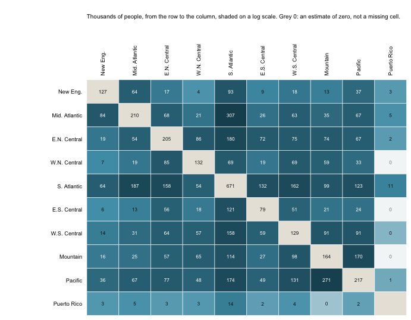

**Figure 2. The same matrix, as a matrix.** Thousands of people moving from the row’s division to the column’s, shaded on a log scale, so each step of shading is a tenfold increase rather than a fixed number of people; the diagonal is moves that changed state without leaving the division. Hover any cell for the estimate, its margin of error, and how many suppressed state pairs are inside it. The button switches to net flow, and blanks every pair whose net is smaller than its own margin of error.

Press it. **Most of the matrix goes blank**, and what is left is a small number of genuinely directional exchanges sitting in a field of churn. That is the honest picture of American migration, and no chord diagram can draw it, because a ribbon has no way to say *this taper is not distinguishable from parallel*. The trade runs the other way too: the matrix cannot show at a glance that the Pacific division sends people almost everywhere while East South Central mostly trades with its neighbours. Figure 1 hands you that in a second and will not surrender a single value.

Why does any of this matter to democracy? Because House seats are apportioned by population, and population moves.

| Division | Arrived | Left | Net | Net per 1000 | House seats 2020 |
| --- | --- | --- | --- | --- | --- |
| East South Central | 473,482 | 389,310 | +84,172 | 4.27 | 26 |
| Mountain | 827,891 | 735,394 | +92,497 | 3.57 | 33 |
| South Atlantic | 1,901,317 | 1,661,721 | +239,596 | 3.47 | 85 |
| West South Central | 801,009 | 696,509 | +104,500 | 2.45 | 53 |
| West North Central | 488,769 | 493,085 | -4,316 | -0.20 | 29 |
| New England | 377,932 | 385,241 | -7,309 | -0.48 | 21 |
| East North Central | 790,360 | 833,263 | -42,903 | -0.91 | 62 |
| Puerto Rico | 22,456 | 36,401 | -13,945 | -4.37 | 0 |
| Pacific | 830,562 | 1,070,577 | -240,015 | -4.50 | 71 |
| Middle Atlantic | 674,566 | 886,843 | -212,277 | -5.05 | 55 |

The 5 divisions losing people on net hold 238 House seats between them; the 4 gaining hold 197. Middle Atlantic loses 5.0 people per thousand residents a year and East South Central gains 4.3, and a decade of that is what the apportionment brief is recomputing when the seat totals change. The rates are small, and that is the point worth carrying away. Nothing in Figure 1 looks like an exodus, yet a net flow of a few people per thousand per year, sustained for a decade, reorganises the House of Representatives. That is why this table is published annually and read cumulatively.

## What this brief cannot tell you

**Anything the grouping did not decide first.** Nine divisions is 99 ribbons; fifty-two units would be 2,652 and unreadable. Every finding above would change under a different list: how much cancels, which pairs stand out, what counts as “within”. The Census divisions are a 1910 committee decision, not a natural kind, and a grouping by metropolitan area or by cost of living would draw a different circle from identical numbers.

**A trend.** This is a single ACS release. The 26.9% of moves that stay inside a division and the 12.1% median net are one year’s estimates. The migration brief carries the long series, in which American mobility has been falling for decades.

**The suppressed cells.** The 279 missing state pairs were added as zeros, and they are the smallest flows between the smallest states, so the rim segments for the least populated divisions are the least trustworthy. They cannot be recovered from the published state totals either, because the ACS estimates its cells and its totals separately and they do not add up.

**Why anybody moved, or whether they moved back.** Somebody who left Pennsylvania for Florida and returned the next year appears twice, in opposite directions, and contributes nothing to any net. That is not an error in the data; it is what the data is. The word for it is churn, and it is 87.9% of what the median pair of divisions did to each other.

## What you should have learned

- **26.9% of interstate moves never cross a division boundary**, so a circle drawn from nine groups reads as staying put even though every one of its 7,188,344 moves changed state. Aggregation is a decision with consequences, made before the first pixel is drawn.
- Migration is mostly churn: across the 45 division pairs the median net is 12.1% of the gross flow, and only 12.6% of all between-division movement is net.
- Only 21 of the 45 division nets, and 6 of the 10 region nets, are larger than their own margins of error, because a net inherits the uncertainty of both estimates it is built from.
- The one-way exodus is the exception, not the rule: Middle Atlantic–South Atlantic is the most directional large exchange in the country, and even there 75.6% of the movement cancelled.
- A chord diagram shows the shape of a whole flow grid at a glance and will not surrender a number; the matrix does the opposite. Neither replaces the other.

## Extensions

- `pairs.csv` has `a_to_b`, `b_to_a`, `gross`, `net` and `net_pct_of_gross`. Sort by the last one. Which pairs are a genuine one-way move, and which are two large flows that almost cancel?
- Count the TRUE rows in the `net_sig` column of `pairs.csv`. What is left of the story about Americans moving between regions once the nets that cannot be told apart from zero are set aside?
- `matrix.csv` records how many state pairs were `suppressed` in each cell. Does suppression fall evenly across the grid, or does it land on particular kinds of place?
- `states.csv` maps each state to both a `division` and a `region`. Regroup the flows by region and compare: does the picture change, and would you have known if you had only ever seen one grouping?
- **Stretch.** Download the previous year’s release of the same Bureau table, from the address in the sources below with the year changed, and rebuild the division pairs. Do the same nets clear their margins, or does the set churn?
- **Stretch.** Invent a grouping of your own, by which party carried the state or by cost of living, and reaggregate the state flows in a spreadsheet using your list. Does the exodus story look stronger or weaker than under the Bureau’s 1910 map?

## Sources

**Data**

- U.S. Census Bureau. *State-to-State Migration Flows*, American Community Survey 2024 one-year estimates, table T13. The figures here read the tables this book’s migration brief hands over, which describes the 279 suppressed pairs. https://www2.census.gov/programs-surveys/demo/tables/geographic-mobility/2024/state-to-state-migration/State_to_State_Migration_Table_2024_T13.xlsx
- U.S. Census Bureau. *Geographic Areas Reference Manual*, chapter 6, on the four regions and nine divisions. The state-to-division assignment is read from this book’s regional-shift brief; `states.csv` writes the assignment out again so it can be checked state by state. https://www2.census.gov/geo/pdfs/reference/GARM/Ch6GARM.pdf
- U.S. Census Bureau. *2020 Census Apportionment Results*, as committed by this book’s apportionment brief. https://www.census.gov/data/tables/2020/dec/2020-apportionment-data.html
- U.S. Census Bureau (2020). *Understanding and Using American Community Survey Data: What All Data Users Need to Know*, Appendix 3, on aggregating estimates and their margins of error — the source of the quadrature rule used here. https://www.census.gov/programs-surveys/acs/library/handbooks/general.html

**Academic literature**

- Krzywinski, Martin et al. (2009). “Circos: an information aesthetic for comparative genomics.” *Genome Research* 19(9): 1639–1645. The paper that made the chord diagram a standard form, and the source of the layout in Figure 1. https://pmc.ncbi.nlm.nih.gov/articles/PMC2752132/

**The data itself**

Every figure above is drawn from these tables. They are plain CSV, they open in a spreadsheet, and they are yours to take further.

`arcs.csv`, `groups.csv`, `matrix.csv`, `pairs.csv`, `states.csv`

One more file is not data about the subject – it is how this chapter checked its own numbers: `facts.csv`, the individual numbers the text above quotes.

[^1]: The regions and divisions are defined in chapter 6 of the Bureau’s *Geographic Areas Reference Manual*, https://www2.census.gov/geo/pdfs/reference/GARM/Ch6GARM.pdf.
[^2]: U.S. Census Bureau, *Understanding and Using American Community Survey Data: What All Data Users Need to Know* (2020), appendix 3, https://www.census.gov/programs-surveys/acs/library/handbooks/general.html.